# FUNCIONES Y SUS LÍMITES

## EL LÍMITE DE UNA FUNCIÓN

```
El propósito de este sección es explorar el significado del límite de una función. Comenzaremos mostrando como la idea de un límite surge cuando tratamos de en contrar la velocidad de un objeto en caída.
```

#### Ejemplo

Suponga que una pelota es soltada de la parte superior de una torre, de 450 metros de alto. Encontrar la velocidad de la pelota despues de cinco segundos.

```python
h0 = 0
g = 9.81
h(t) = 450 - (1/2)*g*t^2
```

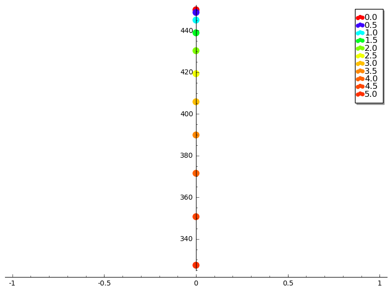

```python
simulacion = Graphics()

import numpy as np
tiempos = np.linspace(0,5,num=11,endpoint=True)

for t0 in tiempos:
    simulacion += point((0, h(t0)), color=hue(2^-t0), size=100, legend_label=t0)

show(simulacion)
```

Lo primero que se nos podría ocurrir es calcular la velocidad promedio

```python
velocidad_promedio = (h(5)-h(0))/(5-0)
print(velocidad_promedio)
```

```
-24.5250000000000
```

Sin embargo, es importante notar que si elegimos intervarlos cada vez más pequeño para calcular esta velocidad promedio, obtendremos resultados diferentes.

```python
for t0 in tiempos:
    try:
        velocidad_promedio = (h(5)-h(t0))/(5-t0)
        print(t0, velocidad_promedio)
    except:
        print(t0, "Division entre 0")
```

```
(0.0, -24.5250000000000)
(0.5, -26.9775000000000)
(1.0, -29.4300000000000)
(1.5, -31.8825000000000)
(2.0, -34.3350000000000)
(2.5, -36.7875000000000)
(3.0, -39.2400000000000)
(3.5, -41.6925000000000)
(4.0, -44.1450000000000)
(4.5, -46.5975000000000)
(5.0, 'Division entre 0')
```

¿Qué sucede si intentamos repetir el procedimiento, pero ahora sólo en el intervalo $[4,5]$?

```python
tiempos = np.linspace(4,5,num=11,endpoint=True)

for t0 in tiempos:
    try:
        velocidad_promedio = (h(5)-h(t0))/(5-t0)
        print(t0, velocidad_promedio)
    except:
        print(t0, "Division entre 0")
```

```
(4.0, -44.1450000000000)
(4.0999999999999996, -44.6355000000000)
(4.2000000000000002, -45.1260000000000)
(4.2999999999999998, -45.6165000000000)
(4.4000000000000004, -46.1070000000000)
(4.5, -46.5975000000000)
(4.5999999999999996, -47.0879999999999)
(4.7000000000000002, -47.5785000000000)
(4.7999999999999998, -48.0689999999998)
(4.9000000000000004, -48.5594999999997)
(5.0, 'Division entre 0')
```

Ahora, repitamos esto mismo, pero en el intervalo $[4.9, 5]$

```python
tiempos = np.linspace(4.9,5,num=11,endpoint=True)

for t0 in tiempos:
    try:
        velocidad_promedio = (h(5)-h(t0))/(5-t0)
        print(t0, velocidad_promedio)
    except:
        print(t0, "Division entre 0")
```

```
(4.9000000000000004, -48.5594999999997)
(4.9100000000000001, -48.6085500000002)
(4.9199999999999999, -48.6575999999999)
(4.9300000000000006, -48.7066499999998)
(4.9400000000000004, -48.7557000000003)
(4.9500000000000002, -48.8047499999995)
(4.96, -48.8538000000005)
(4.9699999999999998, -48.9028499999995)
(4.9800000000000004, -48.9518999999983)
(4.9900000000000002, -49.0009499999996)
(5.0, 'Division entre 0')
```

Podemos conjeturar que la velocidad promedio en intervalos cada vez más cortos, se aproxima a `-49m/s`. Repitamos una última vez este procedimiento.

```python
tiempos = np.linspace(4.99,5,num=11,endpoint=True)

for t0 in tiempos:
    try:
        velocidad_promedio = (h(5)-h(t0))/(5-t0)
        print(t0, velocidad_promedio)
    except:
        print(t0, "Division entre 0")
```

```
(4.9900000000000002, -49.0009499999996)
(4.9910000000000005, -49.0058549999962)
(4.992, -49.0107600000016)
(4.9930000000000003, -49.0156649999991)
(4.9939999999999998, -49.0205699999990)
(4.9950000000000001, -49.0254749999973)
(4.9960000000000004, -49.0303799999961)
(4.9969999999999999, -49.0352850000003)
(4.9980000000000002, -49.0401900000049)
(4.9989999999999997, -49.0450949999804)
(5.0, 'Division entre 0')
```

Sin embargo, ¡cuánto más nos acercamos a `t=5.0`, no empezamos a alejar un poco más de `v=-49`! De hecho, **la respuesta correcta es `v=-49.05`.** Esto nos muestra que los cálculos numérico por si mismos, no siempre nos tan precisos como creyeramos. Por eso, nos es necesario realizar un análisis matemático cauteloso de este tipo de fenómenos físicos.

De hecho, lo que estamos tratando de cálcular es el límite de la velocidad promedio cuando el cambio en el tiempo es aproximadamente cero. Al valor que obtenemos se le llama *velocidad instantanea*.

Antes de entrar en la parte teórica, calculemos este límite con `Sagemath`:

```python
velocidad_promedio(t) = (h(5)-h(t))/(5-t)

velocidad_instantanea = limit(velocidad_promedio(t), t=5)

print(velocidad_instantanea)
```

```
-49.050000000000004
```

No es díficil entender porque la respuesta es esta. Observemos primero la gráfica de la velocidad promedio:

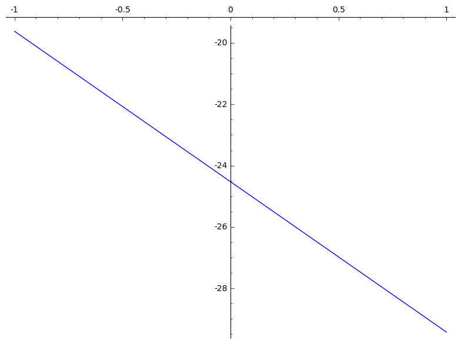

```python
plot(velocidad_promedio)
```

En efecto, ¡su gráfica es una recta! Incluso podemos obtener su expresión algebraica:

```python
show(velocidad_promedio)
```

$$\newcommand{\Bold}[1]{\mathbf{#1}}t \ {\mapsto}\ -\frac{4.90500000000000 \, t^{2} - 122.625000000000}{t - 5}$$

La cual se simplifica

```python
show(velocidad_promedio.factor())
```

$$\newcommand{\Bold}[1]{\mathbf{#1}}-\frac{981}{200} \, t - \frac{981}{40}$$

El detalle es que si intentamos evaluar en `t=5` en la expresión original, obtendremos una horrible división entre de cero. Ahora, si simplificamos la expresión, no es díficil evaluar en este punto, **¡pero la única manera de simplificar es removiendo dicho punto!** De aquí surgió la idea de los límites.

### Definición intuitiva de límite.

#### Ejercicio

- Cálcule numericamente el límite de la función $f(x)=x^2-x+2$, cuando $x$ se aproxima a `2` (lo cual escribiremos como $x\to 2$), tal como lo hicimos en el ejercicio anterior.
- En el ejercicio anterior sólo lo aproximamos usando valores de `x` menores al punto límite. Ahora intente calcularlo, usando valores mayores que `x=2`.

#### Definición (intuitiva)

Suponga que $f(x)$ está definida cuando $x$ está cercano a un número $c$. Entonces decimos que el límite de $f(x)$ cuando $x$ se aproxima a $c$ es igual a $L$ si podemos hacer que los valores de $f(x)$ sean *arbitrariamente* cercanos a $L$ tomando valores de $x$ suficientemente cercanos (pero no iguales) a $c$.

En este caso escribimos $$ L = \lim_{x\to c} f(x) $$

#### Ejercicio

- Intente encontrar numéricamente $$ \lim_{x \to 1} \dfrac{x-1}{x^2-1} $$.
- ¿Es posible cálcularlos sólo sustituyendo en $x=1$?

#### Ejercicio

- Intente encontrar numéricamente $$ \lim_{t \to 0} \dfrac{\sqrt{t^2+9} - 3}{t^2} $$.
- ¿Es posible cálcularlos sólo sustituyendo en $t=0$?

#### Ejercicio

- Intente encontrar numéricamente $$ \lim_{x \to 0} \dfrac{\sin(x)}{x} $$.
- ¿Es posible cálcularlos sólo sustituyendo en $x=0$?

#### Ejercicio

- Investigue $$ \lim_{x\to 0} \sin\left(\dfrac{\pi}{x}\right) $$
- Trace la gráfica de esta función

### Límites unilaterales

#### Ejemplo

En la física matemática, es posible encontrar funciones definidas a trozo que no son *continuas*. Por ejemplo, la función de *Heaviside*:

$$ H(t)= \begin{cases} 0 & t<0 \\ 1 & t\geq 0 \end{cases} $$

```
1
```

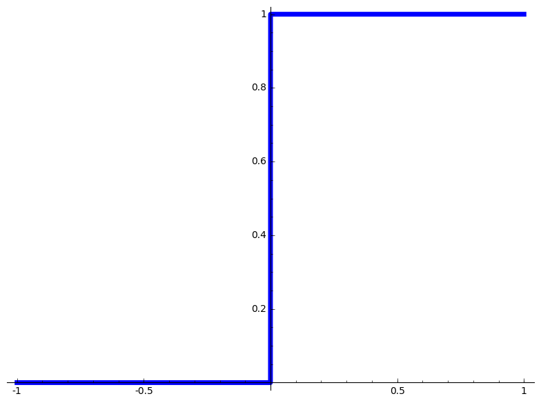

```python
negativos = (-infinity, 0)
cero = [0,0]
positivos = (0, infinity)

definicion_a_trozos = [
    [negativos,0],
    [cero,1],
    [positivos,1] ]

H(x) = piecewise(definicion_a_trozos)
print(H(0))

plot(H, (t,-1,1), thickness=5)
```

Si calculamos el límite cuando $t\to 0$ por la izquierda, obtenemos el límite $L=0$

```python
negativos = np.linspace(-1,0,num=10)
for x in negativos:
    print(x, H(x))
```

```
(-1.0, 0)
(-0.88888888888888884, 0)
(-0.77777777777777779, 0)
(-0.66666666666666674, 0)
(-0.55555555555555558, 0)
(-0.44444444444444442, 0)
(-0.33333333333333337, 0)
(-0.22222222222222232, 0)
(-0.11111111111111116, 0)
(0.0, 1)
```

Si calculamos el límite cuando $t\to 0$ por la derecha, obtenemos el límite $L=1$

```python
positivos = np.linspace(1,0,num=10)
for x in positivos:
    print(x, H(x))
```

```
(1.0, 1)
(0.88888888888888884, 1)
(0.77777777777777779, 1)
(0.66666666666666674, 1)
(0.55555555555555558, 1)
(0.44444444444444442, 1)
(0.33333333333333337, 1)
(0.22222222222222232, 1)
(0.11111111111111116, 1)
(0.0, 1)
```

Sin embargo, hay un salto o *discontinuidad*, ya que los valores de $H$ a la izquierda de $t=0$ son exactamente 0, pero en $t=0$, $H$ es igual a uno:

```python
print(H(0))
```

```
1
```

Para diferenciar el valor del límite calculado a partir de la aproximación por lados diferentes, utilizamos la siguiente notación:

- $x \to c^-$ si la aproximación es desde $-\infty$, es decir, por la izquierda
- $x \to c^+$ si la aproximación es desde $+\infty$, es decir, por la derecha

Entonces, escribiremos $$\lim_{x\to c^-} f(x)$$ para el límite (lateral) que obtenemos por la izquierda y $$\lim_{x\to c^+} f(x)$$ para el límite (lateral) que obtenemos por la derecha.

En el ejemplo de la función de Heaviside, tendríamos que $$\lim_{x\to c^-} H(x) = 0$$ $$\lim_{x\to c^-} H(x) = 1$$

Observe que el límite bilateral sólo puede definirse si existen los límites laterales y estos coinciden. Resumiendo tenemos que

#### Proposición

$$\lim_{x\to c} f(x) = L$$ si y solo si $$\lim_{x\to c^-} f(x)=\lim_{x\to c^+} f(x)$$

Antes de continuar con los cálculos numéricos, procedamos a realizar un ejercicio de comprensión

#### Ejercicio

[figure not shown]

Calcule los siguientes límites:

- $$\lim_{x\to 2^-} g(x)$$
- $$\lim_{x\to 2^+} g(x)$$
- $$\lim_{x\to 2} g(x)$$
- $$\lim_{x\to 5^-} g(x)$$
- $$\lim_{x\to 5^+} g(x)$$
- $$\lim_{x\to 5} g(x)$$

#### Ejercicio

Determine si $$ \lim_{x\to 0} \dfrac{1}{x^2} $$ existe.